# The many faces of stereotype threat: Group- and self-threat - ScienceDirect

- [View **PDF**](https://www.sciencedirect.com/science/article/pii/S0022103107000984/pdfft?md5=8705251fe21ae5d529076bc21e21f470&pid=1-s2.0-S0022103107000984-main.pdf)

## [Journal of Experimental Social Psychology](https://www.sciencedirect.com/journal/journal-of-experimental-social-psychology)

[Volume 44, Issue 3](https://www.sciencedirect.com/journal/journal-of-experimental-social-psychology/vol/44/issue/3), May 2008, Pages 792-799

# The many faces of stereotype threat: Group- and self-threat☆

https://doi.org/10.1016/j.jesp.2007.07.005[Get rights and content](https://s100.copyright.com/AppDispatchServlet?publisherName=ELS&contentID=S0022103107000984&orderBeanReset=true)

## Abstract

Contending with negative intellectual stereotypes has been shown to depress the [academic performance](https://www.sciencedirect.com/topics/psychology/academic-performance) of targets of the stereotypes [Steele, C. M. (1997). A threat in the air: How stereotypes shape intellectual identity and performance. *American Psychologist*, *52*, 613–629]. The present paper examines whether women’s mathematics performance is differentially affected by the concern of confirming that a negative stereotype is true of the self (self-threat), than by the concern of confirming that the stereotype is true of their gender (group-threat). In two studies we independently manipulated these different threats for women taking a mathematics test. Gender identification moderated the effect of group-threats on test performance; only women highly identified with their gender underperformed. The performance of less gender-identified women was unaffected by group-threats. In contrast, gender identification did not moderate the effect of self-threats—both high- and low-identified women underperformed. The results of these studies suggest that women’s math performance is differentially affected by the source of the threat.

## Keywords

Stereotype threat

Stereotyping

Stigma

Self and identity

Gender

Being negatively stereotyped can be an unpleasant experience (Allport, 1954). S*tereotype threat theory* suggests that having to contend with stereotypes that allege intellectual incompetence can depress the academic performance of women and ethnic minorities (Steele, 1997). While research on stereotype threat has burgeoned, the nature of the “threat” remains unclear. Emphasizing the ambiguous nature of stereotype threat, Aronson and colleagues asked, “Is stereotype threat self-threatening because it arouses a fear of being a bad ambassador of one’s group to mainstream society? Or is it more simply the apprehension about appearing incompetent—for the sake of one’s own reputation?” (Aronson, Lustina, Good, Keough, & Steele, 1999, p. 43). The present research explores whether stereotype threat can consist of at least two distinct types of threats—concerns about demonstrating that a negative stereotype is true of one’s group (group-threat), and concerns about demonstrating that a negative stereotype is true of oneself (self-threat).

## The “Threat” in stereotype threat

Stereotype threat occurs when individuals become aware that a negative stereotype can be used as a basis for interpreting their [behavior](https://www.sciencedirect.com/topics/neuroscience/behavior-neuroscience) (Steele, 1997). Specifically, stereotype threat has been defined as “the discomfort targets feel when they are at risk of fulfilling a negative stereotype about their group; the apprehension that they could behave in such a way as to confirm the stereotype—in the eyes of others, in their own eyes, or both at the same time” (Aronson, Quinn, & Spencer, 1998, pp. 85–86). Concerns about confirming a negative stereotype have been shown to depress the [academic performance](https://www.sciencedirect.com/topics/psychology/academic-performance) of the women in math settings and ethnic minorities in academic settings more broadly (Spencer et al., 1999, Steele and Aronson, 1995).

Despite consistently demonstrating the stereotype threat effect, researchers have yet to clearly determine the actual nature of the threat. One commonly held view is that stereotype threat impairs performance by forcing targets to contend with the possibility of being personally viewed through the lens of the stereotype. Thus, stereotype threat might be driven by targets’ awareness that they could possibly confirm to others, or even to themselves, that the stereotype is personally true of them (Aronson et al., 1998, Inzlicht and Ben-Zeev, 2003, Steele, 1997).

Consistent with this view, stereotype threat has been shown to increase targets’ concerns about how they will be perceived. For example, in an attempt to prevent others from applying the “unintelligent” stereotype to them, Black students reported less interest in stereotypically Black activities when they knew their intelligence was being assessed (Steele & Aronson, 1995, Experiment 3). Similarly, Black students’ awareness that a same-race peer was struggling on a standardized intelligence test increased their concerns about being personally viewed as unintelligent. As a result of these concerns, these students experienced decreased self-esteem and depressed test performance (Cohen & Garcia, 2005). Thus, it appears that stereotype threat might be driven by concerns about being personally reduced to a negative stereotype.

Another view is that stereotype threat depresses performance by forcing targets to contend with the possibility of confirming that a negative stereotype is true of their social group. From this perspective, stereotype threat is driven by targets’ concerns about possibly being a bad ambassador of their social group. In academic settings, women and students of color are acutely aware that others might use their performance as proof that their social group lacks intellectual competence (Steele, 1997). Thus, stereotype threat may be triggered by targets’ motivation to prove that the stereotype is not true of their group. Supporting this view, research has shown that the targets of negative stereotypes feel added pressure to disconfirm the stereotypic beliefs that others have of their group (Lord and Saenz, 1985, Pollak and Niemann, 1998, Sekaquaptewa and Thompson, 2002). This added pressure, ironically, can result in poor academic outcomes (Steele, Spencer, & Aronson, 2002). Thus, the fear of being a bad ambassador of one’s group may also trigger stereotype threat.

## Different possible types of threats

Further complicating matters, researchers have used various means of invoking stereotype threat. For instance, stereotype threat has been initiated by emphasizing the evaluative nature of the test (Davies et al., 2002, Steele and Aronson, 1995); by highlighting group differences in performance (Spencer et al., 1999); by manipulating the proportion of targets and non-targets in the testing environment (Inzlicht and Ben-Zeev, 2000, Sekaquaptewa and Thompson, 2002); by making group membership or group identity salient (Shih, Pittinsky, & Ambady, 1999); as well as by combining these manipulations (Schmader, 2002, Sekaquaptewa and Thompson, 2003, Spencer et al., 1999).

While this diversity in manipulating stereotype threat has increased the generalizability of the effect, it has also created ambiguity regarding the actual nature of the threat. While most researchers have described stereotype threat as a single threat, it is conceivable that different manipulations might trigger different types of threats (Aronson et al., 1999, Shapiro and Neuberg, 2007). Manipulations that emphasize that targets’ intellectual competence will be evaluated (e.g., diagnostic test) might trigger stereotype threat by invoking concerns about being personally reduced to the negative stereotype. In contrast, manipulations that emphasize the relevance of the stereotype to the image of the target’s social group (e.g., investigating [gender differences](https://www.sciencedirect.com/topics/psychology/gender-difference) in ability) might trigger stereotype threat by increasing their concerns about confirming, as well as motivation to disconfirm, that the stereotype is true of the entire social group.

Our assertion is that stereotype threat is not a single threat, but actually consists of at least two distinct types of threats—self-threats and group-threats. Whether one threat, or both, is invoked depends upon the social context. Self-threats should be invoked in contexts that highlight the relevance of a negative stereotype to one’s personal image. In academic contexts, competence is highly valued. As a result, students are motivated to present themselves as being intellectually competent. Stereotypes that allege incompetence create a self-image threat by jeopardizing targets’ ability to project an image of competence (Crocker, Garcia, & Nuer, in press). Thus, targets should become concerned about how they will be personally perceived in contexts where a stereotype of incompetence can be applied. These concerns should result in impaired [academic performance](https://www.sciencedirect.com/topics/psychology/academic-performance).

In contrast, group-threats should be invoked in social contexts in which a negative stereotype calls into question the competence of one’s social group. When the group’s image is threatened by a negative stereotype, targets should be concerned about potentially being a poor ambassador of their group. This concern should in turn create a pressure to disconfirm the stereotype. This pressure to disconfirm the stereotype should be most strongly felt by individuals who are highly identified with the negatively stereotyped group (Schmader, 2002) because they derive personal meaning and value from their group membership (Tajfel & Turner, 1986). Thus, when the “bad at math” stereotype threatens the image of women as a group, highly identified women should be concerned about confirming the stereotype, and feel the pressure to disprove it as well. Ironically, this should impair their performance on math-related tasks. Individuals who are less identified with the stereotyped group should be less concerned about the image of the group, and therefore their math performance should not be affected by group-threats.

In two studies, we examine whether or not stereotype threat consists of two distinct threats. Study 1 explores whether self-threats and group-threats can independently impair women’s math performance, while Study 2 explores whether group identification moderates the effect of these threats on math performance.

## Study 1

### Method

#### Participants and design

Sixty-two female undergraduates from a large mid-western university participated in this study for course credit. Three participants were excluded because they did not report their SAT-Math scores (SAT-M), leaving a sample of 59 participants. Participants were randomly assigned to one of four experimental conditions—non-diagnostic, diagnostic, group-threat, and self-threat.

#### Procedure

Participants arrived at the laboratory individually and were greeted by a female experimenter. The experimenter provided oral test instructions that comprised the experimental manipulation. In the *non-diagnostic condition*, the experimenter told the participants that the purpose of the study was to assess the [cognitive processes](https://www.sciencedirect.com/topics/psychology/cognitive-process) involved in solving math problems. In addition, the experimenter informed participants that the test had been shown to be unrelated to math competence, and therefore could not assess their math ability. Finally, the experimenter told the participants to try their best, even though their math ability would not be evaluated. Similar test descriptions have been shown to decrease stereotype threat effects, and thus served as the control condition (Steele & Aronson, 1995).

To ensure that we obtained the standard stereotype threat effect, we included the *diagnostic testing condition* used in previous stereotype threat studies (Steele & Aronson, 1995). The experimenter told participants in this condition that the purpose of the study was to investigate the cognitive factors involved in solving [mathematical problems](https://www.sciencedirect.com/topics/psychology/mathematical-problem). Furthermore, the experimenter stated that the test was designed to measure their math ability, and that they would receive feedback on their performance at the end of the study. Finally the experimenter encouraged the participants to try their best because their math ability was being assessed. The evaluative nature of the test, coupled with feedback from the evaluator, has been shown to invoke stereotype threat.

The third experimental condition was the *self-threat condition*. The aim of this condition was to emphasize to the participants that the stereotype could be used to interpret their math ability, while deemphasizing the relevance of the stereotype in interpreting their gender’s math ability. The experimenter provided the same test instructions as in the diagnostic condition, with one important modification. In the diagnostic condition the experimenter explicitly told participants that they would be provided with performance feedback at the end of the study, however in the self-threat condition the experimenter told participants that they would grade their own test. The experimenter stressed to the participants that they would be the only person who would know their test score. To further assure the participants that their scores would be completely private, the experimenter instructed them to avoid writing any personally identifying information on their test. The experimenter then told the participants that upon completing the test, they should insert it into the middle of a pile of previously completed tests. Finally, the experimenter encouraged the participants to try their best, even though they would be the only person who would know their test score.

This latter manipulation was designed to provide a stringent test of a self-threat. As previously mentioned, we characterize self-threats as resulting from targets having to contend with the threat of confirming to others, or to themselves, that the stereotype is personally true of them. We reasoned that removing the possibility of confirming the stereotype to others provided the most conservative test of a self-threat. It is the removal of external evaluation that distinguishes the self-threat condition from the diagnostic condition. In the diagnostic condition the participants could potentially confirm the stereotype to others and to themselves, while in the self-threat condition the participants could only confirm the stereotype to themselves.

This self-threat manipulation mirrors research by Inzlicht and Ben-Zeev (2003), which showed that women experienced stereotype threat even when they knew that no one else would know their math score. Due to the anonymous nature of the self-threat condition, participants were aware that their performance could not be used as evidence that they were not good at math, or as evidence that women were not good at math. Thus, the primary concern for participants in the self-threat condition was that they could demonstrate to themselves that the stereotype was true of them personally.

The aim of the *group-threat condition* was to emphasize to the participants that the stereotype could be used to interpret their gender’s math ability, while deemphasizing the relevance of the stereotype in interpreting their personal math ability. In this condition, the experimenter informed participants that the purpose of the study was to investigate [gender differences](https://www.sciencedirect.com/topics/psychology/gender-difference) in math ability. In addition, the experimenter stated that the researchers were not interested in the participant’s individual math score. Instead, the researchers planned to compare the average score of the female participants with the average score of the male participants. To ensure that the participants were aware that their performance would be based solely on their gender membership, the experimenter explicitly instructed the participants not to write their name on their test; instead they were instructed to write only their gender at the top of their test. The experimenter then told the participants that after completing the test, they should place their test in one of two bins that were designated by gender. Each bin contained tests that were ostensibly completed by prior participants. Finally, the experimenter encouraged the participants to try their best, even though their score would be averaged with those of other participants of their gender.

It is important to note that in the group-threat condition, self-threats were minimized because neither the participants, nor the researchers, could use the participants’ performance as evidence that the stereotype was true of them personally. Thus, the participants’ primary concern should be that their performance could confirm to the researchers that the stereotype is true of women. This manipulation is different from previous stereotype threat studies that have manipulated the relevance of gender differences in math ability (e.g., Schmader, 2002, Spencer et al., 1999). In the threat condition in previous studies, participants were told about gender differences in math performance and that their math ability would be evaluated. This type of manipulation should invoke both self- and group-threats because the participants’ performance has implications for how they would be personally perceived, as well as for how their entire social group would be perceived. In contrast, the group-threat manipulation minimized the self-threat component by removing the implications of their performance for how they would personally be perceived. Thus, the primary concern participants should have is how women as a group would be perceived.

After reciting the test instructions, the experimenter gave all participants a 20-item mathematical test. Following the test, the participants reported their scores on the math section of the Scholastic Aptitude Test (SAT-M), answered some demographic questions, and then were fully debriefed.

#### Materials

##### Mathematical test

Students took the “Necessary Arithmetic Operations” test from the Educational Testing Service Kit (French, Ekstrom, & Price, 1963). This test requires test-takers to identify the operation(s) needed to correctly solve 20 mathematical word problems in 7 min. While participants had to identify the correct operation, they did not actually solve the word problem. This test was successfully used in previous stereotype threat research conducted by Danso and Esses (2001). The [dependent variables](https://www.sciencedirect.com/topics/psychology/dependent-variable) were the number of questions answered correctly and test accuracy.

### Results and discussion

#### SAT-M

Since participants’ self-reported SAT-M scores were significantly correlated with both number correct and test accuracy (*r* = .49, *p* < .001 and *r* = .47, *p* < .001 respectively), SAT-M was included as a covariate in all analyses. As anticipated with random assignment, there were no differences in participants’ SAT-M scores across experimental conditions (*F* = .77, *ns*).

#### Number correct

Table 1. Mean number correct and accuracy as a function of experimental condition (Study 1)

| Dependent variables | Experimental condition Non-diagnostic *n* = 14 | Experimental condition Diagnostic *n* = 16 | Experimental condition Self-threat *n* = 14 | Experimental condition Group-threat *n* = 15 |
| --- | --- | --- | --- | --- |
| Number correct | 13.75<sub>a</sub> (2.41) | 11.13<sub>b</sub> (2.42) | 11.93<sub>b</sub> (2.87) | 12.40<sub>a,b</sub> (2.23) |
| Test accuracy | 0.89<sub>a</sub> (0.08) | 0.79<sub>a,b</sub> (0.19) | 0.78<sub>b</sub> (0.19) | 0.81<sub>a,b</sub> (0.12) |

*Note.* Means with different subscripts in the same row differ significantly from one another (*p* < .05). The numbers in brackets () are the standard deviations. The non-diagnostic test description served as the control condition.

#### Test accuracy

Study 1 tested whether stereotype threat could affect women’s math performance through different routes. Consistent with previous research, women who took a test that could assess their [mathematical ability](https://www.sciencedirect.com/topics/psychology/mathematical-ability) (diagnostic) underperformed in comparison to women in the control condition (non-diagnostic). Similarly, when the women were able to assess their own ability in private (self-threat), their test performance suffered compared to women in the control condition. In contrast, the test performance of women who took a test investigating gender differences in math (group-threat) did not differ from women in the control condition.

Why were there no performance differences between participants in the control condition and participants in the group-threat condition? We believe that there are two likely explanations. First, the participants in the group-threat condition may have felt less pressure to disconfirm the stereotype because their experimenter was also a woman. Consistent with this reasoning, research has shown that the presence of ingroup members can minimize group-threat concerns because people can assume that ingroup members are unlikely to endorse ingroup stereotypes (Sekaquaptewa and Thompson, 2002, Wout et al., (under review)). If this is the case, a group-threat should have a greater effect on women’s performance when their experimenter is male. In order to explore this possibility we replaced the female experimenter with a male experimenter in Study 2.

Another possible reason for the null finding is that group-threats are moderated by group identification. Both social identity (Tajfel, 1981, Tajfel and Turner, 1986) and self-categorization theory (Turner, Hogg, Oakes, Reicher, & Wetherell, 1987) posit that people use group membership as a source of self-worth. People who place value and importance on their group membership should be highly motivated to represent the group in a positive light. Thus, when highly gender identified women experience a gender-based group-threat, they should feel the added pressure to disprove the “bad at math” stereotype. This added pressure should depress math performance (Steele et al., 2002). For women who are not identified with their gender, a gender group-threat should not create this pressure to disconfirm the stereotype, and therefore it should have no effect on their math performance.

Supporting this logic, Schmader (2002) found that stereotype threat had a more detrimental effect on the math performance of highly gender-identified women than less gender-identified women. It is important to note, however, that Schmader (2002) used a multiple threat approach in which participants were informed that their personal ability was being evaluated (self-threat), and that gender differences in math ability was also being investigated (group-threat). Due to this multiple threat manipulation, it remains unclear if gender identification moderates group-threats, self-threats, or both.

Study 2 investigates the extent to which gender identification moderates the effects of self- and group-threats. We predict that gender identification will moderate the effect when the group is threatened, but not when the self is threatened.

## Study 2

### Method

#### Participants and design

Fifty-nine female undergraduates from a small liberal arts university participated in this study in exchange for course credit. Data from four women were excluded because they did not report their SAT-M, thus leaving a sample of 55 women. Participants were randomly assigned to one of three experimental conditions: non-diagnostic (*n* = 19), self-threat (*n* = 18), and group-threat (*n* = 18).

#### Measures

##### Gender identification

Participants completed the Importance Subscale of the Collective Self-Esteem Measure (Luhtanen & Crocker, 1992), modified for gender, during a mass-testing session at the beginning of the semester. A sample item is “The gender group that I belong to is an important reflection of who I am.” Participants indicated their responses on a 7-point [Likert scale](https://www.sciencedirect.com/topics/psychology/likert-scale), with higher scores indicating higher gender identification. The mean gender identification score was 4.83 (*SD* = 1.17), (Cronbach’s alpha = .71).

#### Procedure

The procedures were identical to those in Study 1, with two important modifications. First, the diagnostic condition from Study 1 was removed, thus leaving only 3 experimental conditions. Also, the female experimenter from Study 1 was replaced with a male experimenter.

### Results and discussion

#### SAT-M and gender identification

As in Study 1, SAT-M was used as a covariate in all test performance analyses. As expected, there were no condition differences in SAT-M scores (*F* = .20, *ns*) or gender identification (*F* = 1.03, *ns*). Furthermore, gender identification was not correlated with SAT-M scores (*r* = .09, *ns*).

#### Number correct

We predicted that women in the self-threat condition would underperform on the test relative to women in the non-diagnostic condition. Furthermore, we predicted that gender identification would only moderate the performance of women in the group-threat condition, such that the stronger their gender identification, the poorer they would perform on the test. To test these predictions, participants’ test scores were regressed on their gender identification (mean centered), the experimental condition, and the interaction between gender identification and experimental condition, controlling for SAT scores (see Aiken & West, 1991). Because the experimental condition had three levels, it was effect coded with two vertices (“*group,*” a contrast between the non-diagnostic control and group-threat conditions, where non-diagnostic = −1, self-threat = 0, group-threat = 1 and “*self,*” a contrast between the non-diagnostic control and the self-threat condition, where non-diagnostic = −1, group-threat = 0, and self-threat = 1).

Analyses revealed a marginally significant effect for condition, *β* = −.25, *t* (48) = −1.77, *p* < .08. Mean comparisons revealed that participants in the non-diagnostic condition performed significantly better (*M* = 15.47) than did participants in either the self-threat condition (*M* = 13.56), Cohen’s *d* = 0.82, or the group-threat condition (*M* = 13. 61), Cohen’s *d* = 0.77. In addition, gender identity was a marginally significant predictor, such that the more participants reported identifying with their gender, the fewer questions they answered correctly, *β* = −.22, *t*(48) = −1.76, *p* = .09. Consistent with our prediction, these two effects were qualified by a significant gender identification by experimental condition interaction. Specifically, the interaction between gender identification and the contrast between the non-diagnostic condition and the group-threat condition was significant, *β* = −.45, *t*(48) = −3.10, *p* = .005. Simple slopes analyses revealed that among participants in the group-threat condition, higher gender identification was associated with fewer questions answered correctly, *β* = −.68, *t* = −3.41, *p* = .005. However, among participants in the non-diagnostic and self-threat conditions, gender identification was uncorrelated with number correct, *β* = .05, *t* = .21, *ns* and *β* = .02, *t* = .08, *ns,* respectively (see Fig. 1).

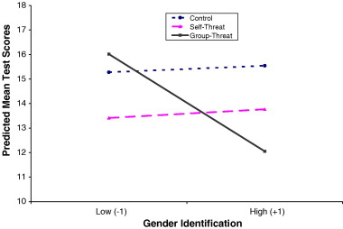

1. [Download : Download full-size image](https://ars.els-cdn.com/content/image/1-s2.0-S0022103107000984-gr1.jpg)

Fig. 1. Number correct as a function of experimental condition and gender identification (Study 2).

#### Test accuracy

A similar [regression analysis](https://www.sciencedirect.com/topics/psychology/regression-analysis) was conducted on participants’ test accuracy. Results revealed a significant effect for condition, *β* = −.30, *t*(48) = −2.17, *p* < .05. Mean comparisons revealed that participants in the non-diagnostic condition were significantly more accurate (*M* = 90%) than participants in the self-threat condition (*M* = 79%), Cohen’s *d* = 1.01, or the group-threat condition (*M* = 80%), Cohen’s *d* = 0.98. Gender identification was also a significant predictor; the more participants reported identifying with their gender, the less accurate they were on the test, *β* = −.27, *t*(48) = −2.19, *p* < .05. As predicted, these effects were qualified by a significant gender identification by experimental condition interaction. In particular, the interaction between gender identification and the contrast between the control condition and the group-threat condition was significant, *β* = −.30, *t* (48) = −2.10, *p* < .05. Similar to the results for number correct, simple slopes analyses revealed that higher gender identification was associated with lower accuracy among participants in the group-threat condition, *β* = −.56, *t* = −2.62, *p* = .05. However, for participants in the non-diagnostic and self-threat conditions, gender identification was not correlated with accuracy, *β* = −.18, *t* = −.74, *ns* and *β* = −.12, *t* = −.57, *ns,* respectively (see Fig. 2).

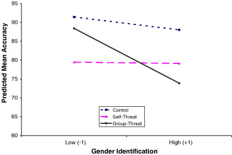

1. [Download : Download full-size image](https://ars.els-cdn.com/content/image/1-s2.0-S0022103107000984-gr2.jpg)

Fig. 2. Test accuracy as a function of experimental condition and gender identification (Study 2).

The results of Study 2 demonstrate that group- and self-threats have different moderators. As predicted, gender identification moderated test performance in the group-threat condition, such that women high in gender identification performed worse than women low in gender identification. In contrast, gender identification did not moderate test performance in the self-threat condition. Both high and low gender identified women in the self-threat condition underperformed in comparison to women in the control condition.

## General discussion

While previous research has shown that stereotype threat negatively affects the academic performance of the targets of the stereotype, there has been a dearth of research on the actual nature of the threat. The present studies attempted to address this issue by demonstrating that there are at least two unique types of threats—self-threats and group-threats. Self-threats are triggered by a concern that one will be personally stereotyped, while group-threats are triggered by a concern that one’s social group will be negatively stereotyped.

Study 1 revealed that, compared to a non-diagnostic condition, women underperformed when faced with the possibility of confirming the math stereotype either to others (diagnostic) or to themselves (self-threat). In contrast, their performance was not affected when faced with the possibility of confirming that the stereotype was true of their gender (group-threat). Study 2 revealed that gender identification moderates the effect of group-threats, but not self-threats. Specifically, highly gender identified women underperformed when faced with a group-threat, but the performance of low gender identified women was unaffected by this threat. Importantly, gender identification did not moderate the performance effects resulting from a self-threat—both high and low gender identified women underperformed when they experienced self-threat. Collectively, these studies suggest that stereotype threat can be invoked independently by self- and group-threat.

### Reconceptualizing threat

Previous research has conceptualized stereotype threat as a single threat. This conceptualization may be oversimplifying the stereotype threat process. A more appropriate approach may be to conceptualize stereotype threat as a broad phenomenon consisting of multiple types of threats. While all these threats center on a concern about having a negative stereotype applied, they differ in whether the concern is that the stereotype will be applied to oneself or to one’s social group. The present research demonstrates that the effect of stereotype threat differs depending on which threat is invoked.

Consistent with our emphasis on a multi-threat approach, a recent theoretical paper proposes that stereotype threat can be divided into various distinct threats (Shapiro & Neuberg, 2007). While there are slight differences between that theoretical paper and our empirical work, they share the common belief that researchers should move away from viewing stereotype threat through a single threat lens, and instead adopt a multi-threat framework.

A multi-threat framework should enable researchers to explore whether group- and self-threats have an additive effect on performance. In most academic settings, women and ethnic minorities often feel that both their personal competence and their group’s competence are viewed with suspicion. Thus, they face the challenge of simultaneously contending with group-threats and self-threats. Over time, this predicament can result in disengagement and disidentification from the stereotyped domain (Major et al., 1998, Steele, 1992). Future research should explore the possible additive effects of self- and group-threats, as well as the immediate and long-term academic consequences of these threats.

Another potential benefit of a multi-threat approach is that it enables researchers to better predict when, and for whom, stereotype threat will have an effect. Various personality characteristics have been shown to moderate stereotype threat (e.g., domain identification; stigma-consciousness; group identification). These differing moderators make it difficult to determine when stereotype threat will occur. A multi-threat approach could potentially address this problem by increasing predictive power. For example, the present research shows that gender identification moderates group-threats but not self-threats. This knowledge will enable researchers to better predict when a group-threat will occur. Another possibility is that stigma-consciousness, with its emphasis on how people believe they would be personally perceived or treated, may moderate self-threats but not group-threats. Thus, research using a multi-threat approach will enable researchers to more precisely predict when individual difference variables will moderate the effect of self- and group-threats.

Along with several potential moderators, research has shown that stereotype threat has a number of potential mediators (Croizet et al., 2004, Davies et al., 2005, O’Brien and Crandall, 2003, Schmader and Johns, 2003, Wout et al., (under review)). A multi-threat approach could potentially allow researchers to better understand when these mediators will drive the stereotype threat effect. While it is possible that self-threats and group-threats have the same mediators, it is also conceivable that they have different mediational processes. A clearer understanding of the mediational processes involved in each type of threat will enable researchers and educators to develop intervention strategies that are tailored to the particular threat(s) that students are experiencing in their academic setting. By doing so, our hope is that the predicament facing the targets of negative stereotypes can be minimized so that they can reach their maximum intellectual potential.

## References

1. Aiken and West, 1991

   L.S. Aiken, S.G. West

   Multiple regression: Testing and interpreting interactions

   Sage Publications, Inc, Thousand Oaks, CA (1991)

   [Google Scholar](https://scholar.google.com/scholar_lookup?title=Multiple%20regression%3A%20Testing%20and%20interpreting%20interactions&publication_year=1991&author=L.S.%20Aiken&author=S.G.%20West)
2. Allport, 1954

   G.W. Allport

   The nature of prejudice

   Addison-Wesley, Reading, MA (1954)

   [Google Scholar](https://scholar.google.com/scholar_lookup?title=The%20nature%20of%20prejudice&publication_year=1954&author=G.W.%20Allport)
3. Aronson et al., 1999

   J. Aronson, M. Lustina, C. Good, K. Keough, C.M. Steele

   When white men can’t do math: Necessary and sufficient factors in stereotype threat

   Google Scholar
4. Aronson et al., 1998

   J. Aronson, D.M. Quinn, S.J. Spencer

   Stereotype threat and the academic underperformance of minorities and women

   J.K. Swim, C. Stangor (Eds.), Prejudice: The target’s perspective, Academic Press, New York (1998), pp. 83-103

   [View PDF](https://www.sciencedirect.com/science/article/pii/B9780126791303500399/pdfft?md5=6c669e91e1b4c008d2183201a2d812ae&pid=3-s2.0-B9780126791303500399-main.pdf)[View article](https://www.sciencedirect.com/science/article/pii/B9780126791303500399)Google Scholar
5. Cohen and Garcia, 2005

   G. Cohen, J. Garcia

   I am us: Negative stereotypes as collective threats

   Journal of Personality and Social Psychology, 89 (2005), pp. 566-582

   [CrossRef](https://doi.org/10.1037/0022-3514.89.4.566)[View in Scopus](https://www.scopus.com/inward/record.url?eid=2-s2.0-27944474437&partnerID=10&rel=R3.0.0)[Google Scholar](https://scholar.google.com/scholar_lookup?title=I%20am%20us%3A%20Negative%20stereotypes%20as%20collective%20threats&publication_year=2005&author=G.%20Cohen&author=J.%20Garcia)

   6

   228

   1
6. Crocker et al., in press

   Crocker, J., Garcia, J. A., & Nuer, N. (in press). From egosystem to ecosystem in intergroup interactions: Implications for intergroup reconciliation. In J. Fisher, A. Nadler, & T. Molloy (Eds.), *Intergroup reconciliation*. Oxford: Oxford University Press.

   Google Scholar
7. Croizet et al., 2004

   J.C. Croizet, G. Despres, M. Gauzins, P. Huguet, J. Leyens, *et al.*

   Stereotype threat undermines intellectual performance by triggering a disruptive mental load

   Personality and Social Psychology Bulletin, 30 (2004), pp. 721-731

   [View in Scopus](https://www.scopus.com/inward/record.url?eid=2-s2.0-2442455612&partnerID=10&rel=R3.0.0)Google Scholar
8. Davies et al., 2002

   P.G. Davies, S.J. Spencer, D.M. Quinn, R. Gerhardstein

   Consuming images: How television commercials that elicit stereotypes can restrain women academically and professionally

   Personality and Social Psychology Bulletin, 28 (2002), pp. 1615-1628

   [View in Scopus](https://www.scopus.com/inward/record.url?eid=2-s2.0-23044534145&partnerID=10&rel=R3.0.0)Google Scholar
9. Davies et al., 2005

   P.G. Davies, S.J. Spencer, C.M. Steele

   Clearing the air: Identity safety moderates the effects of stereotype threat on women’s leadership aspirations

   Journal of Personality and Social Psychology, 88 (2005), pp. 276-287

   [CrossRef](https://doi.org/10.1037/0022-3514.88.2.276)[View in Scopus](https://www.scopus.com/inward/record.url?eid=2-s2.0-13444266475&partnerID=10&rel=R3.0.0)Google Scholar

   11

   491

   1
10. Danso and Esses, 2001

    H.A. Danso, V.M. Esses

    Black experimenters and the intellectual test performance of White participants: The tables are turned

    Journal of Experimental Social Psychology, 37 (2001), pp. 158-165

    [View PDF](https://www.sciencedirect.com/science/article/pii/S0022103100914446/pdfft?md5=91cdb097d63d965d51c35c2c54fb6346&pid=1-s2.0-S0022103100914446-main.pdf)[View article](https://www.sciencedirect.com/science/article/pii/S0022103100914446)[View in Scopus](https://www.scopus.com/inward/record.url?eid=2-s2.0-0035592452&partnerID=10&rel=R3.0.0)Google Scholar

    0

    0

    0
11. French et al., 1963

    J.W. French, K.B. Ekstrom, L.A. Price

    Kit of reference tests for cognitive factors

    Educational Testing Service, Princeton, NJ (1963)

    [Google Scholar](https://scholar.google.com/scholar_lookup?title=Kit%20of%20reference%20tests%20for%20cognitive%20factors&publication_year=1963&author=J.W.%20French&author=K.B.%20Ekstrom&author=L.A.%20Price)
12. Inzlicht and Ben-Zeev, 2000

    M. Inzlicht, T. Ben-Zeev

    A threatening intellectual environment: Why females are susceptible to experiencing problem-solving deficits in the presence of males

    Psychological Science, 11 (2000), pp. 365-371

    [CrossRef](https://doi.org/10.1111/1467-9280.00272)[View in Scopus](https://www.scopus.com/inward/record.url?eid=2-s2.0-0034279620&partnerID=10&rel=R3.0.0)Google Scholar

    30

    535

    3
13. Inzlicht and Ben-Zeev, 2003

    M. Inzlicht, T. Ben-Zeev

    Do high-achieving female students underperform in private? The implications of threatening environments on intellectual processing

    Journal of Educational Psychology, 95 (2003), pp. 796-805

    [View in Scopus](https://www.scopus.com/inward/record.url?eid=2-s2.0-0345581710&partnerID=10&rel=R3.0.0)Google Scholar
14. Lord and Saenz, 1985

    C.G. Lord, D.S. Saenz

    Memory deficits and memory surfeits: Differential cognitive consequences of tokenism for tokens and observers

    Journal of Personality and Social Psychology, 49 (1985), pp. 918-926

    [View in Scopus](https://www.scopus.com/inward/record.url?eid=2-s2.0-0022137709&partnerID=10&rel=R3.0.0)Google Scholar
15. Luhtanen and Crocker, 1992

    R. Luhtanen, J. Crocker

    A collective self-esteem scale: Self-evaluations of one’s social identity

    Personality and Social Psychology Bulletin, 24 (1992), pp. 34-50

    [Google Scholar](https://scholar.google.com/scholar_lookup?title=A%20collective%20self-esteem%20scale%3A%20Self-evaluations%20of%20ones%20social%20identity&publication_year=1992&author=R.%20Luhtanen&author=J.%20Crocker)
16. Major et al., 1998

    B. Major, S. Spencer, T. Schmader, C. Wolfe, J. Crocker

    Coping with negative stereotypes about intellectual performance: The role of psychological disengagement

    Personality and Social Psychology Bulletin, 24 (1998), pp. 34-50

    [CrossRef](https://doi.org/10.1177/0146167298241003)[View in Scopus](https://www.scopus.com/inward/record.url?eid=2-s2.0-0032340276&partnerID=10&rel=R3.0.0)Google Scholar

    16

    313

    4
17. O’Brien and Crandall, 2003

    L. O’Brien, C.S. Crandall

    Stereotype threat and arousal: Effects on women’s math performance

    Personality and Social Psychology Bulletin, 29 (2003), pp. 782-789

    [View in Scopus](https://www.scopus.com/inward/record.url?eid=2-s2.0-0038793813&partnerID=10&rel=R3.0.0)[Google Scholar](https://scholar.google.com/scholar_lookup?title=Stereotype%20threat%20and%20arousal%3A%20Effects%20on%20womens%20math%20performance&publication_year=2003&author=L.%20O%E2%80%99Brien&author=C.S.%20Crandall)
18. Pollak and Niemann, 1998

    K.I. Pollak, Y.F. Niemann

    Black and White tokens in academia: A difference of chronic versus acute distinctiveness

    Journal of Applied Social Psychology, 28 (1998), pp. 954-972

    [CrossRef](https://doi.org/10.1111/j.1559-1816.1998.tb01662.x)[View in Scopus](https://www.scopus.com/inward/record.url?eid=2-s2.0-0032081301&partnerID=10&rel=R3.0.0)Google Scholar

    40

    2

    32

    0
19. Schmader, 2002

    T. Schmader

    Gender identification moderates stereotype threat effects on women’s math performance

    Journal of Experimental Social Psychology, 38 (2002), pp. 194-201

    [View PDF](https://www.sciencedirect.com/science/article/pii/S0022103101915008/pdf?md5=601c80a2c3af702a27788096d0b55e84&pid=1-s2.0-S0022103101915008-main.pdf)[View article](https://www.sciencedirect.com/science/article/pii/S0022103101915008)[View in Scopus](https://www.scopus.com/inward/record.url?eid=2-s2.0-0036122581&partnerID=10&rel=R3.0.0)[Google Scholar](https://scholar.google.com/scholar_lookup?title=Gender%20identification%20moderates%20stereotype%20threat%20effects%20on%20womens%20math%20performance&publication_year=2002&author=T.%20Schmader)

    0

    0

    0

    0
20. Schmader and Johns, 2003

    T. Schmader, M. Johns

    Converging evidence that stereotype threat reduces working memory capacity

    Journal of Personality and Social Psychology, 85 (2003), pp. 440-452

    [View in Scopus](https://www.scopus.com/inward/record.url?eid=2-s2.0-0141483797&partnerID=10&rel=R3.0.0)[Google Scholar](https://scholar.google.com/scholar_lookup?title=Converging%20evidence%20that%20stereotype%20threat%20reduces%20working%20memory%20capacity&publication_year=2003&author=T.%20Schmader&author=M.%20Johns)
21. Sekaquaptewa and Thompson, 2002

    D. Sekaquaptewa, M. Thompson

    The differential effects of solo status on members of high and low status groups

    Personality and Social Psychology Bulletin, 28 (2002), pp. 694-707

    [CrossRef](https://doi.org/10.1177/0146167202288013)[View in Scopus](https://www.scopus.com/inward/record.url?eid=2-s2.0-23044532967&partnerID=10&rel=R3.0.0)Google Scholar

    149

    5

    122

    1
22. Sekaquaptewa and Thompson, 2003

    D. Sekaquaptewa, M. Thompson

    Solo status, stereotype threat, and performance expectancies: Their effects on women’s performance

    Journal of Experimental Social Psychology, 39 (2003), pp. 68-74

    [View PDF](https://www.sciencedirect.com/science/article/pii/S0022103102005085/pdfft?md5=093c5449752649768ac17be33b28e5a0&pid=1-s2.0-S0022103102005085-main.pdf)[View article](https://www.sciencedirect.com/science/article/pii/S0022103102005085)[View in Scopus](https://www.scopus.com/inward/record.url?eid=2-s2.0-0037279516&partnerID=10&rel=R3.0.0)Google Scholar

    0

    0

    0

    0
23. Shapiro and Neuberg, 2007

    J.R. Shapiro, S.L. Neuberg

    From stereotype threat to stereotype threats: Implications of a multi-threat framework for causes, moderators, mediators, consequences, and interventions

    Personality and Social Psychology Review, 11 (2007), pp. 107-130

    [CrossRef](https://doi.org/10.1177/1088868306294790)[View in Scopus](https://www.scopus.com/inward/record.url?eid=2-s2.0-38749119068&partnerID=10&rel=R3.0.0)Google Scholar

    20

    403

    2
24. Shih et al., 1999

    M.J. Shih, T. Pittinsky, N. Ambady

    Stereotype susceptibility: Identity salience and shifts in quantitative performance

    Psychological Science, 10 (1999), pp. 80-83

    [CrossRef](https://doi.org/10.1111/1467-9280.00111)[View in Scopus](https://www.scopus.com/inward/record.url?eid=2-s2.0-0007129111&partnerID=10&rel=R3.0.0)Google Scholar

    34

    842

    3
25. Spencer et al., 1999

    S.J. Spencer, C.M. Steele, D.M. Quinn

    Stereotype threat and women’s math performance

    Journal of Experimental Social Psychology, 35 (1999), pp. 4-28

    [View PDF](https://www.sciencedirect.com/science/article/pii/S0022103198913737/pdf?md5=993c1933f91a94c43130f2f6f7863bcd&pid=1-s2.0-S0022103198913737-main.pdf)[View article](https://www.sciencedirect.com/science/article/pii/S0022103198913737)[View in Scopus](https://www.scopus.com/inward/record.url?eid=2-s2.0-0033477763&partnerID=10&rel=R3.0.0)[Google Scholar](https://scholar.google.com/scholar_lookup?title=Stereotype%20threat%20and%20womens%20math%20performance&publication_year=1999&author=S.J.%20Spencer&author=C.M.%20Steele&author=D.M.%20Quinn)

    0

    0

    0

    0
26. Steele, 1992

    C.M. Steele

    Race and the schooling of Black Americans

    Atlantic Monthly (1992), pp. 68-78

    [CrossRef](https://doi.org/10.1080/00306525.1992.9633952)[View in Scopus](https://www.scopus.com/inward/record.url?eid=2-s2.0-0040439118&partnerID=10&rel=R3.0.0)[Google Scholar](https://scholar.google.com/scholar_lookup?title=Race%20and%20the%20schooling%20of%20Black%20Americans&publication_year=1992&author=C.M.%20Steele)

    31

    0

    11

    0
27. Steele, 1997

    C.M. Steele

    A threat in the air: How stereotypes shape intellectual identity and performance

    American Psychologist, 52 (1997), pp. 613-629

    [View in Scopus](https://www.scopus.com/inward/record.url?eid=2-s2.0-0031155092&partnerID=10&rel=R3.0.0)[Google Scholar](https://scholar.google.com/scholar_lookup?title=A%20threat%20in%20the%20air%3A%20How%20stereotypes%20shape%20intellectual%20identity%20and%20performance&publication_year=1997&author=C.M.%20Steele)
28. Steele and Aronson, 1995

    C.M. Steele, J. Aronson

    Stereotype threat and the intellectual test performance of African Americans

    Journal of Personality and Social Psychology, 69 (1995), pp. 797-811

    [View in Scopus](https://www.scopus.com/inward/record.url?eid=2-s2.0-0029411777&partnerID=10&rel=R3.0.0)[Google Scholar](https://scholar.google.com/scholar_lookup?title=Stereotype%20threat%20and%20the%20intellectual%20test%20performance%20of%20African%20Americans&publication_year=1995&author=C.M.%20Steele&author=J.%20Aronson)
29. Steele et al., 2002

    C. Steele, S. Spencer, J. Aronson

    Contending with group image: The psychology of stereotype and social identity threat

    M.P. Zanna (Ed.), Advances in experimental social psychology, Vol. 34, Academic Press, San Diego, CA (2002), pp. 379-440

    [View PDF](https://www.sciencedirect.com/science/article/pii/S0065260102800090/pdfft?md5=a833ea551b52b48718a1b4368ecd6540&pid=1-s2.0-S0065260102800090-main.pdf)[View article](https://www.sciencedirect.com/science/article/pii/S0065260102800090)[View in Scopus](https://www.scopus.com/inward/record.url?eid=2-s2.0-35448985860&partnerID=10&rel=R3.0.0)Google Scholar

    0

    0

    0

    0
30. Tajfel, 1981

    H. Tajfel

    Human groups and social categories: Studies in social psychology

    Cambridge University Press, Cambridge, UK (1981)

    [Google Scholar](https://scholar.google.com/scholar_lookup?title=Human%20groups%20and%20social%20categories%3A%20Studies%20in%20social%20psychology&publication_year=1981&author=H.%20Tajfel)
31. Tajfel and Turner, 1986

    H. Tajfel, J.C. Turner

    The social identity theory of intergroup behavior

    S. Worchel, W.G. Austin (Eds.), The psychology of intergroup relations, Nelson Hall, Chicago (1986), pp. 7-24

    [View in Scopus](https://www.scopus.com/inward/record.url?eid=2-s2.0-20444472999&partnerID=10&rel=R3.0.0)[Google Scholar](https://scholar.google.com/scholar_lookup?title=The%20social%20identity%20theory%20of%20intergroup%20behavior&publication_year=1986&author=H.%20Tajfel&author=J.C.%20Turner)
32. Turner et al., 1987

    J.C. Turner, M.A. Hogg, P.J. Oakes, S.D. Reicher, M.S. Wetherell

    Rediscovering the social group: A self-categorization

    Blackwell, Oxford, UK (1987)

    Google Scholar
33. Wout et al., (under review)

    Wout, D. A., Shih, M. J., Jackson, J. M., & Sellers, R. M. (under review). Targets as perceivers: How Blacks determine if they will be stereotyped.

    Google Scholar

## Cited by (0)

**<sup>☆</sup>**

This research was supported by an National Science Foundation postdoctoral fellowship awarded to the first author. We thank our research assistants Courtney Bonam and Jonathan Leland.

**<sup>1</sup>**

One possibility is that the experimental manipulations differentially affected the participants’ motivation during the test. We tested this possibility by conducting analyses on the number of questions that the participants’ attempted. In both studies, analyses did not reveal condition differences in the number of questions that participants attempted (*F*’s <1).

[View Abstract](https://www.sciencedirect.com/science/article/abs/pii/S0022103107000984)

Copyright © 2007 Elsevier Inc. All rights reserved.

  Jason K. Clark, …, Meara M. Habashi

  [View PDF](https://www.sciencedirect.com/science/article/pii/S0022103116300890/pdfft?md5=13a9099706f78ba392a3eb59406a8268&pid=1-s2.0-S0022103116300890-main.pdf)

  Stacey R. Finkelstein, …, Paul M. Connell

  [View PDF](https://www.sciencedirect.com/science/article/pii/S0195666318314478/pdfft?md5=fbf275b4dec392fe5374c1e7bfe65534&pid=1-s2.0-S0195666318314478-main.pdf)

  Linda K. Kaye, …, Joseph J. McCann

  [View PDF](https://www.sciencedirect.com/science/article/pii/S0747563217305575/pdfft?md5=540c504e34c935e0cb6b4f74ca41688a&pid=1-s2.0-S0747563217305575-main.pdf)

Citations

Captures

[figure not shown]